# Introducción a LightGBM con R

Carlos A. Torres Cubilla

# ¿Qué es LightGBM?

LightGBM es un framework de *gradient boosting* que utiliza algoritmos de aprendizaje basados en árboles para crear modelos predictivos de manera eficiente y rápida.

## ¿Que significa LightGBM?

- 🔦 **Light** = ligero, rápido, optimizado
  - Se refiere a que es una versión optimizada del algoritmo de Gradient Boosting.
  - Está diseñado para consumir menos memoria y funcionar más rápido que alternativas como XGBoost o Random Forests.
- 📈 **GBM** = *Gradient Boosting Machine*
  - Un tipo de técnica de ensemble learning que genera muchos modelos débiles (generalmente árboles de decisión) de forma secuencial, donde cada modelo aprende de los errores de sus predecesores para crear un modelo fuerte .
  - Se basa en usar el gradiente del error para mejorar paso a paso.

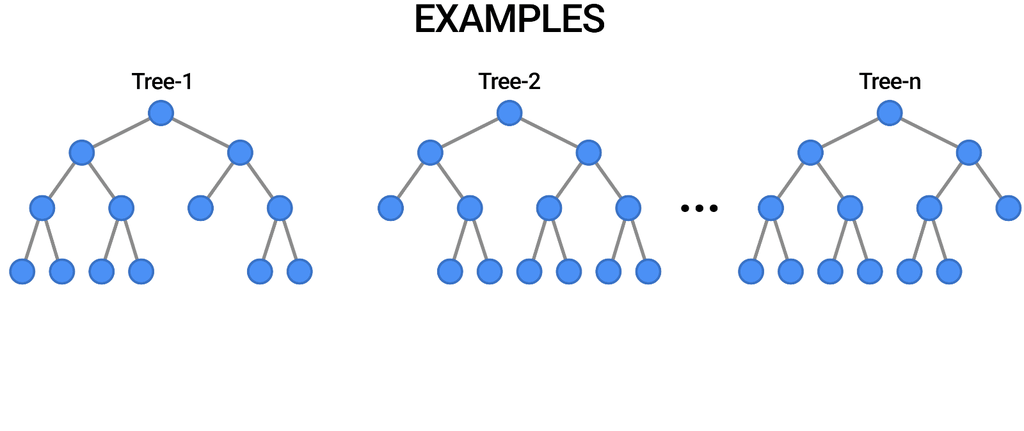

LightGBM mejora los errores paso a paso combinando árboles de decisión pequeños.

## ¿Quién creó LightGBM?

Desarrollado por **Microsoft Research Asia**  
como parte del toolkit **DMTK** (*Distributed Machine Learning Toolkit*).

Lanzado en **2016** como proyecto *open source*.

> *“Creamos LightGBM para resolver problemas del mundo real a gran escala con eficiencia.”*  
> — **Microsoft DMTK Team**

# ¿Qué es Gradient Boosting?

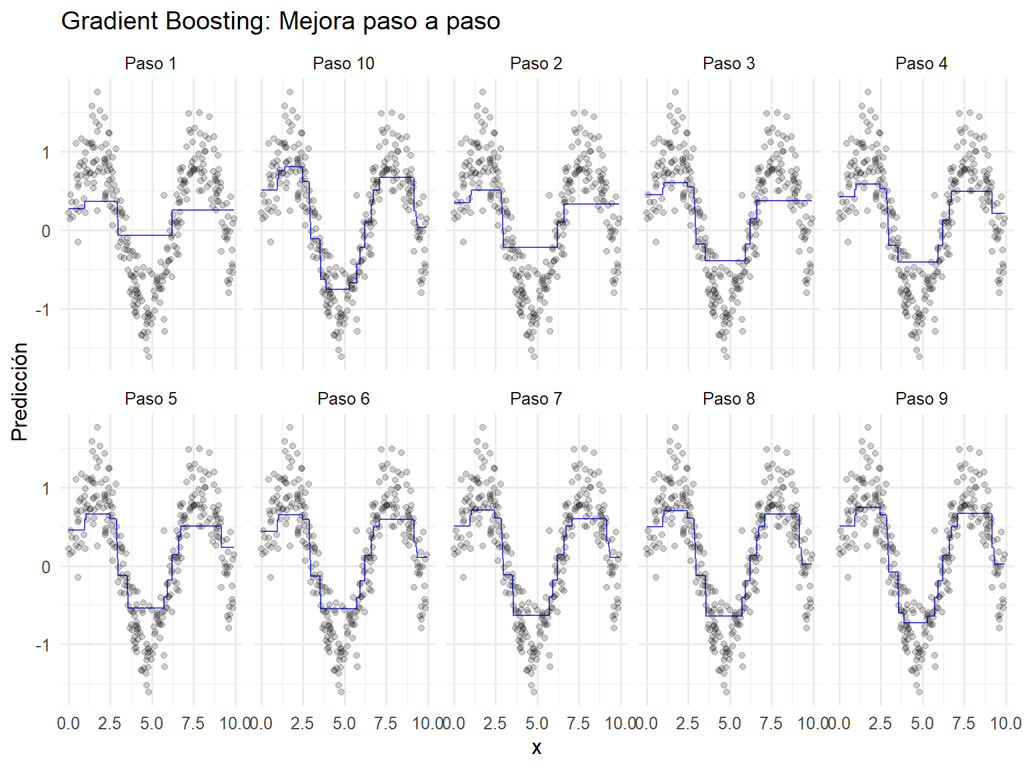

# Ventajas y desventajas

LightGBM se destaca no solo por su rendimiento predictivo, sino también por su eficiencia computacional. Su adopción generalizada en aplicaciones reales de machine learning se puede explicar mediante cinco ventajas clave.

## Ventajas

⚡

Velocidad

💾

Memoria

🎯

Precisión

🖥️

Paralelismo

📊

Escalabilidad

| Ventaja | Descripción |
| --- | --- |
| Velocidad | Entrena modelos rápidamente, lo que lo hace ideal para proyectos con grandes volúmenes de datos |
| Memoria | Optimiza el consumo de memoria, permitiendo trabajar con datasets grandes sin requerir tanta RAM |
| Precisión | Proporciona resultados precisos y competitivos en tareas de predicción |
| Paralelismo | Aprovecha múltiples núcleos, clústeres y aceleración por GPU para entrenamientos más rápidos |
| Escalabilidad | Maneja grandes volúmenes de datos sin pérdida de rendimiento |

## Desventajas

⚠️

Overfitting

🔍

Difícil de interpretar

📉

Problemas en datasets pequeños

🧠

Curva de aprendizaje

🔌

Soporte parcial en entornos

| ⚠️ Desventaja | 📝 Descripción |
| --- | --- |
| Overfitting | Al ser muy poderoso, puede memorizar ruido si no se ajusta correctamente. |
| Difícil de interpretar | Es una “caja negra” frente a modelos más simples como regresión lineal. |
| Problemas en datasets pequeños | Modelos simples pueden generalizar mejor en conjuntos de datos chicos. |
| Curva de aprendizaje | Muchos hiperparámetros que requieren experiencia para ajustar bien. |
| Soporte parcial en entornos | APIs disponibles, pero algunas integraciones pueden ser limitadas o inestables. |

# ¿Para qué utilizar LightGBM?

LightGBM es altamente versátil que permite resolver una amplia variedad de problemas, desde tareas tradicionales como clasificación y regresión, hasta aplicaciones más complejas como ranking, detección de fraude y sistemas de recomendación personalizados. Esto lo convierte en una herramienta poderosa y escalable para proyectos de aprendizaje automático en entornos reales.

[interactive chart not shown]

Muchísimas empresas en todo el mundo utilizan LightGBM debido a su velocidad y precisión para resolver distintos problemas de machine learning. Algunos ejemplos de compañías líderes que han implementado LightGBM en sus soluciones para estos casos de uso:

[figure not shown]

Clasificación

**Microsoft**

Categorizar correos y detectar spam

[figure not shown]

Regresión

**Uber**

Estimar demanda y tiempos de llegada

[figure not shown]

Ranking

**LinkedIn**

Ordenar resultados de búsqueda y recomendaciones de empleo

[figure not shown]

Detección de fraude

**PayPal**

Detectar transacciones sospechosas en tiempo real

[figure not shown]

Sistemas de recomendación

**Netflix**

Personalizar sugerencias de contenido

# Instalación

```r
# Instalar solo si no están instalados
# install.packages("lightgbm", repos = "https://cran.r-project.org")
# install.packages("Matrix")
# install.packages("data.table")

library(lightgbm)
library(Matrix)
library(data.table)
```